# Life Table of Lemurs

## Static vs Cohort life tables: Tracking survivorship

- **Static life table: Based on age distribution at one point in time**
  - infer survivorship across ages
  - age distribution should be stable (representative)
    - if distorted (recent die-off, immigration) then inferred suvivorship will be biased
- **Cohort life table: Follows individuals across time**
  - difficult for long-lived and/or mobile animals

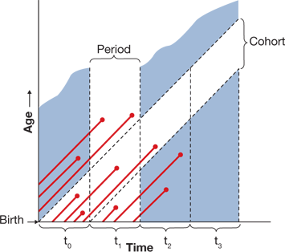

## Understanding life tables (page #1 handout)

- **Age Class (usually years)**
- **Number alive (n<sub>x</sub>)**
- **Survivorship (l<sub>x</sub>): mortality based on starting cohort size**
- **Birthrate per capita (m<sub>x</sub>): average # offspring born to females of each age**
- **Fecundity (F<sub>x</sub>): total number of females produced by females**
- **Net reproductive rate(R): Survivorship x Birthrate (age class)**
  - some will die without making offspring

## Survivorship curves: log(l<sub>x</sub>) versus cohort age

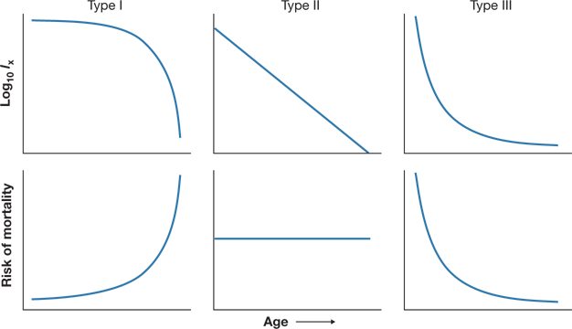

## Survivorship curves: constructed for a cohort from life table

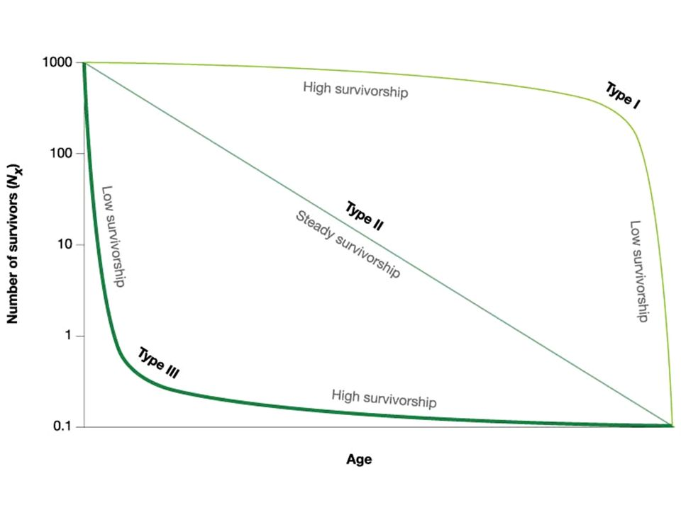

## Verreaux’s Sifakas Lemurs

- **Diurnal primates found in the dry forests of southern Madagascar**
- **Limited range and habitat loss has resulted in Endangered status**
- **Females are socially dominant and territorial**
- **Females have just one infant at a time**
  - Compared to similar sized mammals, sifakas reach reproductive maturity later and live longer
  - r vs K selected species?

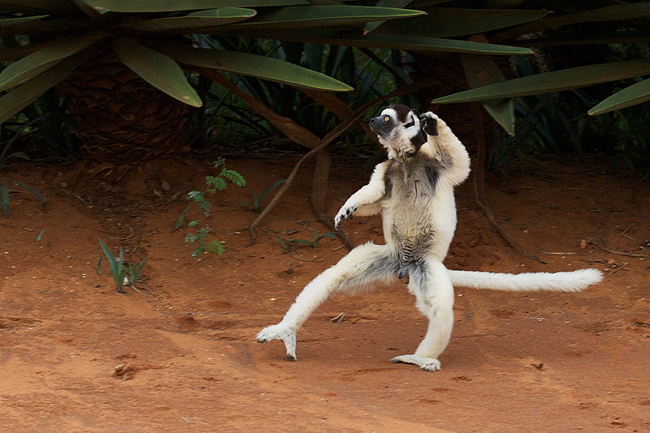

## Richard et al 2002

- **Observational study of a population of sifakas in the Beza Mahafaly Special Reserve in southwest Madagascar**
- **1984 – 1999: Captured 426 animals**
  - Each animal tagged and aged based on tooth wear
  - Recorded gender, survival and fertility through time
  - No females under 3 years old gave birth.
- **Today we will complete a static life stable (1999) to determine whether this threatened population is at risk of extinction**

## Q1. Estimating Birthrate (m<sub>x</sub>) and Fecundity (f<sub>x</sub>)

- **m<sub>x</sub> = per capita birth rate (number of offspring born per individual in age class)**
- **Richard et al. (2002) recorded the proportion of female sifakas of every age (3 – 26) that gave birth in each year from 1984 – 1999**
- **From these data, the median birthrates for 3 year age classes are reported in Table 1 of the handout (page 2)**

## Q1. Estimating Birthrate (m<sub>x</sub>) and Fecundity (f<sub>x</sub>)

- **Life tables often include only data for females, as females limit reproduction**
  - only females add to a population
- **Since N<sub>x</sub> values are for females, we need an m<sub>x</sub> estimate for number of female offspring/female**
- **Does m<sub>x</sub>(3-5) = 0.07?**

## Estimating Birthrate (m<sub>x</sub>) and Fecundity (f<sub>x</sub>)

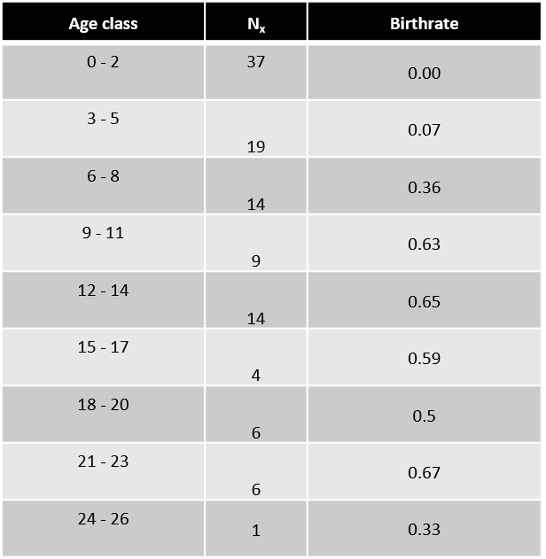

- **Sex ratio matters since our table is constructed for females**
  - assume 1:1 Male:Female
- **Lemurs exhibit a male-biased sex ratio at birth**
  - 46.5 % chance of being a female
- **Female birthrate (m<sub>x</sub>):**
  - Age class 3-5 = .07 x 0.465
- **How would we calculate total number of female births (fecundity, f<sub>x</sub>)?**

## Age-dependent life table

- **Calculate survivorship and maternal reproduction rate as a function of age**
- **In nature, survivorship and reproduction rate depend on numerous factors**
  - temperature, population density, etc.
  - the effect of these factors are encompassed into age class dynamics
- **Population growth parameter (R<sub>o</sub>): Sum of Survivorship x Birth Rate (each age class)**
  - net reproductive rate
  - if R<sub>o</sub> > 1, population is growing
  - R<sub>o</sub> = 2.5 = a female produces 2.5 baby lemurs on average in a lifetime